# Uygulama - Volatilite Modelleri

Finansal Ekonometri (MPİ-TYL)

Prof. Dr. Hüseyin Taştan

Yıldız Teknik Üniversitesi

# 1 Finansal varlık getirilerinin özellikleri

```r
# Install packages
library(wooldridge)
library(dynlm)
library(lmtest)
library(car)
library(forecast)
library(tidyverse)
```

Örnek: S&P500 indeksinin günlük değerleri (quantmod paketiyle indirilmiştir). Önce verileri okutalım:

```r
# SP500 xts full data set (daily min max close)
# 2007-2021
load("../R/Data/SP500.rda")
class(SP500)
```

```
## [1] "tbl_df"     "tbl"        "data.frame"
```

```r
head(SP500)
```

```
## # A tibble: 6 × 7
##   date        open  high   low close     volume adjusted
##   <date>     <dbl> <dbl> <dbl> <dbl>      <dbl>    <dbl>
## 1 2007-01-03 1418. 1429. 1408. 1417. 3429160000    1417.
## 2 2007-01-04 1417. 1422. 1408. 1418. 3004460000    1418.
## 3 2007-01-05 1418. 1418. 1406. 1410. 2919400000    1410.
## 4 2007-01-08 1409. 1415. 1404. 1413. 2763340000    1413.
## 5 2007-01-09 1413. 1416. 1405. 1412. 3038380000    1412.
## 6 2007-01-10 1409. 1416. 1405. 1415. 2764660000    1415.
```

Getiri (return) serisini
$$r_t =
100[\log(P_t)-\log(P_{t-1})]$$
formülüyle hesaplayalım. Burada $P_t$ günlük kapanış (close) fiyatıdır:

```r
SP500 <- SP500 %>%
  mutate(return = 100*(log(close)-lag(log(close), 1, order_by = date)),
         returnsq = return^2,
         range = high-low)
```

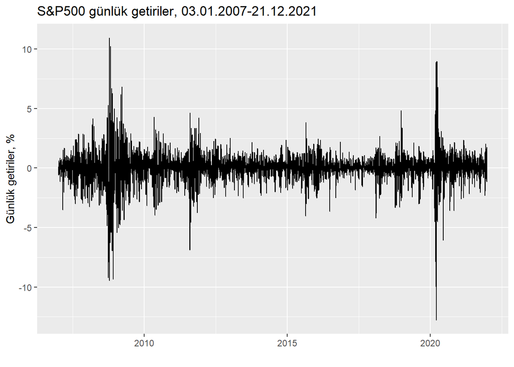

```r
SP500 %>% ggplot(aes(date, return)) +
  geom_line() +
  xlab("") +
  ylab("Günlük getiriler, %") +
  ggtitle("S&P500 günlük getiriler, 03.01.2007-21.12.2021")
```

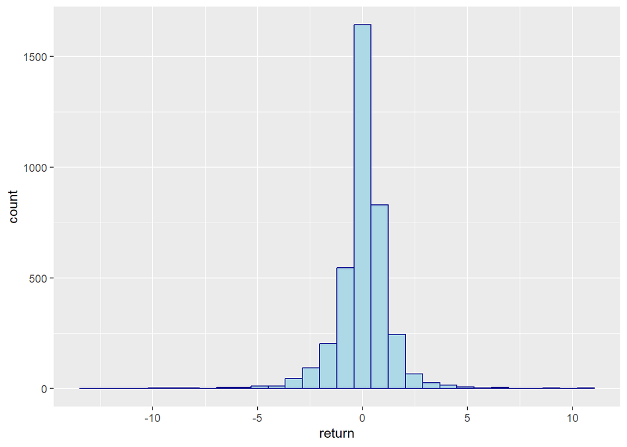

```r
# histogram
SP500 %>% ggplot(aes(return)) +
  geom_histogram(bins = 30,
                 color = "darkblue",
                 fill  = "lightblue")
```

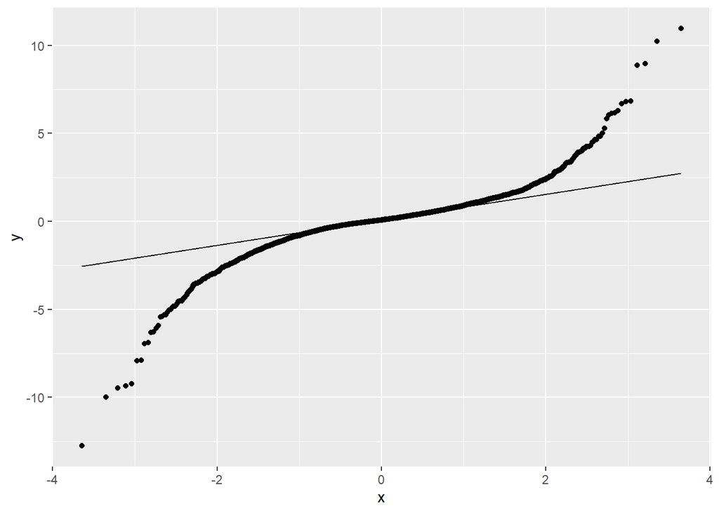

```r
# qqnorm(SP500$return)
# qqline(SP500$return)
# QQ plot
SP500 %>% ggplot(aes(sample=return)) +
  stat_qq() +
  stat_qq_line()
```

QQ grafiğine göre getiri dağılımının normal dağılıma göre çok daha kalın kuyruklu olduğunu görüyoruz.

```r
# çarpıklık ve basıklık
skewness <-  function(x) {
 m3 <- mean((x - mean(x))^3)
 skewness <- m3/(sd(x)^3)
 skewness
}

kurtosis <- function(x) {
 m4 <- mean((x - mean(x))^4)
 kurtosis <- m4/(sd(x)^4)
 kurtosis
}
# K <- kurtosis(return)
# S <- skewness(return)
# JB <- (n/6) * (S^2 + 0.25 * ((K - 3)^2))
# pval <- 1 - pchisq(JB, df = 2)

SP500 %>% drop_na() %>% summarise(mean_ret = mean(return),
                    median_ret = median(return),
                    skewness_ret = skewness(return),
                    kurtosis_ret = kurtosis(return))
```

```
## # A tibble: 1 × 4
##   mean_ret median_ret skewness_ret kurtosis_ret
##      <dbl>      <dbl>        <dbl>        <dbl>
## 1   0.0315     0.0733       -0.561         16.2
```

```r
library(tseries)
tseries::jarque.bera.test(SP500$return[-1])
```

```
##
##  Jarque Bera Test
##
## data:  SP500$return[-1]
## X-squared = 27400, df = 2, p-value < 2.2e-16
```

JB test istatistiği çok büyük bir değer almıştır. P-değeri pratik olarak sıfırdar. Normal dağıldığını söyleyen boş hipotez reddedilir.

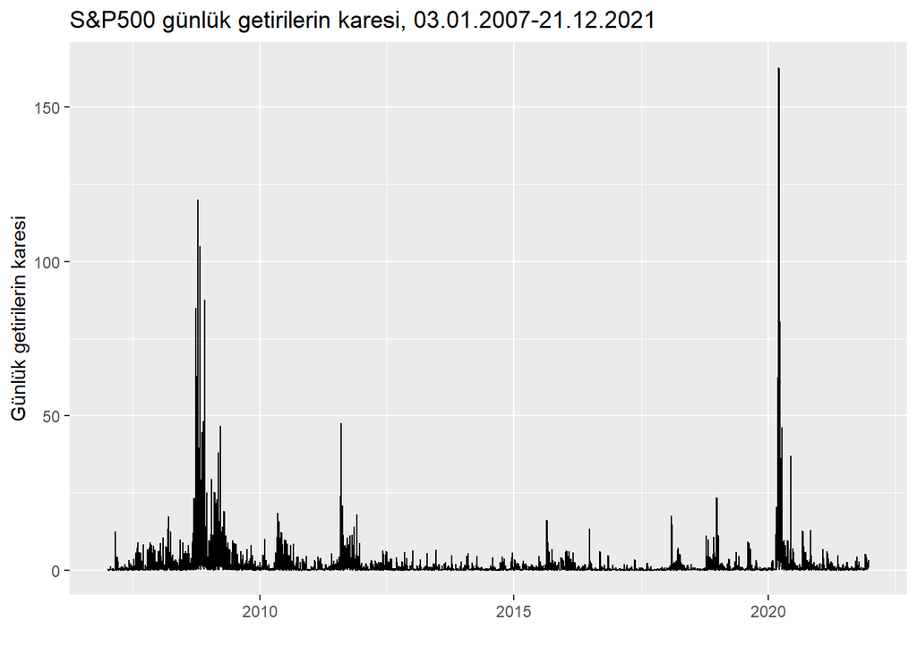

```r
SP500 %>% ggplot(aes(date, returnsq)) +
  geom_line() +
  xlab("") +
  ylab("Günlük getirilerin karesi") +
  ggtitle("S&P500 günlük getirilerin karesi, 03.01.2007-21.12.2021")
```

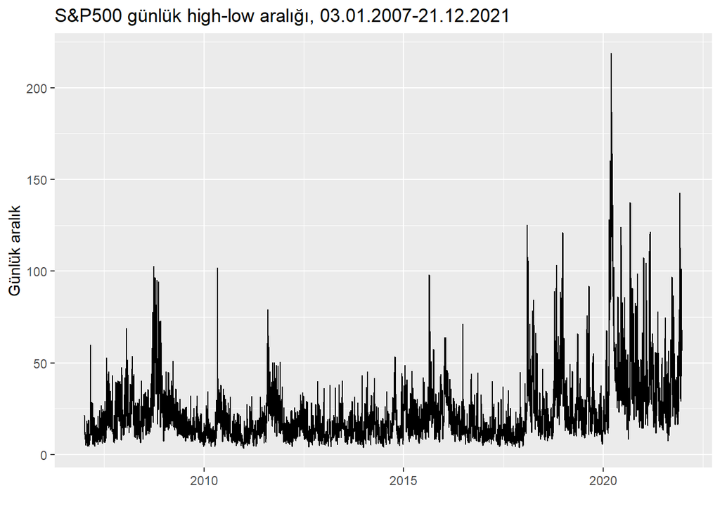

```r
SP500 %>% ggplot(aes(date, range)) +
  geom_line() +
  xlab("") +
  ylab("Günlük aralık") +
  ggtitle("S&P500 günlük high-low aralığı, 03.01.2007-21.12.2021")
```

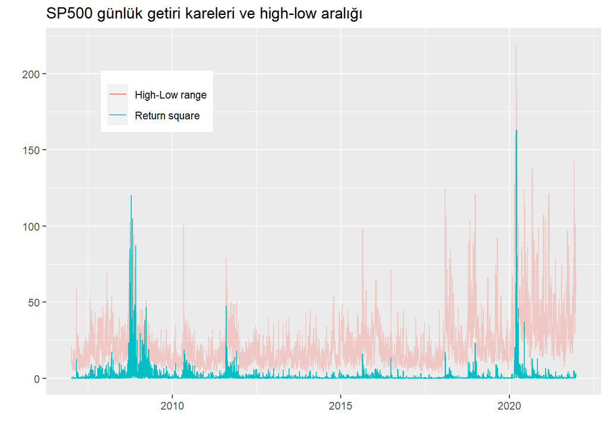

```r
SP500 %>% ggplot(aes(date, range, color = "High-Low range")) +
  geom_line(alpha=0.3) +
  geom_line(aes(date,returnsq, color = "Return square")) +
  xlab("") +
  ylab("") +
  ggtitle("SP500 günlük getiri kareleri ve high-low aralığı") +
  theme(legend.position = c(0.2,0.8),
        legend.title = element_blank())
```

# 2 ARCH Modeli

Derste öğrendiğimiz ARCH testini hesaplayalım. Önce bir ts nesnesi oluşturalım.

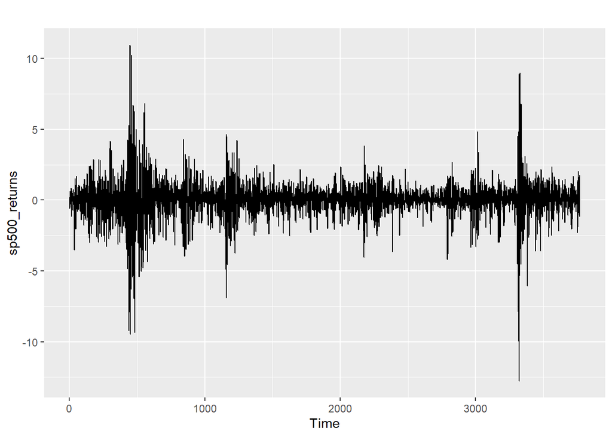

```r
# ARCH effects

# manual test
# ts nesnesi oluştur
sp500_returns <- ts(SP500$return[-1], frequency = 1)
autoplot(sp500_returns)
```

Getiri serisinin ortalamasından farkını alalım. Bunu sabit üzerine regresyonun kalıntılarını alarak hesaplayabiliriz:

```r
library(dynlm)
res1 <- dynlm(sp500_returns ~ 1)
summary(res1)
```

```
##
## Time series regression with "ts" data:
## Start = 1, End = 3769
##
## Call:
## dynlm(formula = sp500_returns ~ 1)
##
## Residuals:
##      Min       1Q   Median       3Q      Max
## -12.7968  -0.4289   0.0417   0.5478  10.9257
##
## Coefficients:
##             Estimate Std. Error t value Pr(>|t|)
## (Intercept)  0.03153    0.02098   1.503    0.133
##
## Residual standard error: 1.288 on 3768 degrees of freedom
```

Kalıntıların karesinin bir gecikmesi üzerine regresyonu:

```r
uhatsq <- residuals(res1)^2

archreg1 <- dynlm(uhatsq ~ L(uhatsq))
summary(archreg1)
```

```
##
## Time series regression with "ts" data:
## Start = 2, End = 3769
##
## Call:
## dynlm(formula = uhatsq ~ L(uhatsq))
##
## Residuals:
##     Min      1Q  Median      3Q     Max
## -40.756  -1.161  -1.003  -0.335 136.431
##
## Coefficients:
##             Estimate Std. Error t value Pr(>|t|)
## (Intercept)  1.10328    0.10234   10.78   <2e-16 ***
## L(uhatsq)    0.33485    0.01535   21.81   <2e-16 ***
## ---
## Signif. codes:  0 '***' 0.001 '**' 0.01 '*' 0.05 '.' 0.1 ' ' 1
##
## Residual standard error: 6.085 on 3766 degrees of freedom
## Multiple R-squared:  0.1121, Adjusted R-squared:  0.1119
## F-statistic: 475.6 on 1 and 3766 DF,  p-value: < 2.2e-16
```

ARCH test istatistiği:

```r
T <- nobs(res1)
q <- length(coef(archreg1))-1
Rsq <- summary(archreg1)$r.squared
LM <- (T-q)*Rsq
LM
```

```
## [1] 422.5001
```

```r
alpha <- 0.05
cv <- qchisq(1-alpha, q) # critical value
cv
```

```
## [1] 3.841459
```

```r
pvalue <- 1-pchisq(LM, q)
pvalue
```

```
## [1] 0
```

ARCH LM = 422.5 olarak hesaplandı. Bu %5 düzeyindeki kritik değerden oldukça büyüktür. ARCH etkisi olmadığını söyleyen boş hipotez reddedilir.

Bu testi yapabileceğimiz bir R paketi:

```r
# finTS paketi ile
library(FinTS)
FinTS::ArchTest(sp500_returns, lags = 1, demean = TRUE)
```

```
##
##  ARCH LM-test; Null hypothesis: no ARCH effects
##
## data:  sp500_returns
## Chi-squared = 422.5, df = 1, p-value < 2.2e-16
```

ARCH modelini tahmin etmek için `{tseries}` veya `{rugarch}` paketlerini kullanabiliriz.

```r
# Tahmin
library(tseries)
# ARCH(1) modeli

arch1 <- garch(sp500_returns, order = c(0, 1))
```

[output not shown]

```r
summary(arch1)
```

```
##
## Call:
## garch(x = sp500_returns, order = c(0, 1))
##
## Model:
## GARCH(0,1)
##
## Residuals:
##      Min       1Q   Median       3Q      Max
## -9.19498 -0.36115  0.06753  0.50939  8.55402
##
## Coefficient(s):
##     Estimate  Std. Error  t value Pr(>|t|)
## a0   0.94884     0.01327    71.51   <2e-16 ***
## a1   0.49453     0.01989    24.86   <2e-16 ***
## ---
## Signif. codes:  0 '***' 0.001 '**' 0.01 '*' 0.05 '.' 0.1 ' ' 1
##
## Diagnostic Tests:
##  Jarque Bera Test
##
## data:  Residuals
## X-squared = 16755, df = 2, p-value < 2.2e-16
##
##
##  Box-Ljung test
##
## data:  Squared.Residuals
## X-squared = 3.8593, df = 1, p-value = 0.04947
```

ARCH(1) modeli tahmin sonuçları:
$$\widehat{\sigma}_t^2 = 0.95 + 0.49~
\hat{u}_{t-1}^2$$

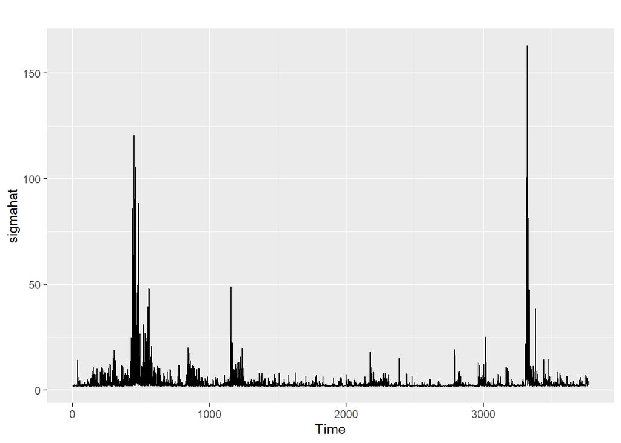

```r
sigmahat <- ts(2*arch1$fitted.values[-1,1]^2)
autoplot(sigmahat)
```

```r
# Kalıntılarda ARCH etkisi var mı
# plot(arch1)
```

```r
# ARCH(2) modeli
arch2 <- garch(sp500_returns, order = c(0, 2))
```

[output not shown]

```r
summary(arch2)
```

```
##
## Call:
## garch(x = sp500_returns, order = c(0, 2))
##
## Model:
## GARCH(0,2)
##
## Residuals:
##      Min       1Q   Median       3Q      Max
## -6.51120 -0.40239  0.07595  0.57958  6.85183
##
## Coefficient(s):
##     Estimate  Std. Error  t value Pr(>|t|)
## a0   0.53681     0.01397    38.44   <2e-16 ***
## a1   0.26407     0.01880    14.05   <2e-16 ***
## a2   0.44402     0.01950    22.77   <2e-16 ***
## ---
## Signif. codes:  0 '***' 0.001 '**' 0.01 '*' 0.05 '.' 0.1 ' ' 1
##
## Diagnostic Tests:
##  Jarque Bera Test
##
## data:  Residuals
## X-squared = 2685.6, df = 2, p-value < 2.2e-16
##
##
##  Box-Ljung test
##
## data:  Squared.Residuals
## X-squared = 3.9113, df = 1, p-value = 0.04796
```

```r
# ARCH(3) modeli
arch3 <- garch(sp500_returns, order = c(0, 3))
```

[output not shown]

```r
summary(arch3)
```

```
##
## Call:
## garch(x = sp500_returns, order = c(0, 3))
##
## Model:
## GARCH(0,3)
##
## Residuals:
##      Min       1Q   Median       3Q      Max
## -6.74746 -0.42556  0.08182  0.59886  4.18101
##
## Coefficient(s):
##     Estimate  Std. Error  t value Pr(>|t|)
## a0   0.38164     0.01264    30.19   <2e-16 ***
## a1   0.17733     0.01573    11.27   <2e-16 ***
## a2   0.38381     0.01647    23.30   <2e-16 ***
## a3   0.26878     0.01969    13.65   <2e-16 ***
## ---
## Signif. codes:  0 '***' 0.001 '**' 0.01 '*' 0.05 '.' 0.1 ' ' 1
##
## Diagnostic Tests:
##  Jarque Bera Test
##
## data:  Residuals
## X-squared = 1904, df = 2, p-value < 2.2e-16
##
##
##  Box-Ljung test
##
## data:  Squared.Residuals
## X-squared = 1.8364, df = 1, p-value = 0.1754
```

# 3 GARCH Modeli

```r
# rugarch paketi ile GARCH modellerinin tahmini
# http://www.unstarched.net/r-examples/rugarch/a-short-introduction-to-the-rugarch-package/
library(rugarch)
```

`{rugarch}` paketi ile GARCH(1,1) modelinin simülasyonu:

```r
garch11_spec = ugarchspec(
  variance.model = list(garchOrder=c(1,1)), # GARCH(1,1) modeli
  mean.model = list(armaOrder=c(0,0)),      # ortalama modeli
  fixed.pars=list(mu = 0,  # simülasyonda kullanılacak parametreler
                  omega = 0.1,
                  alpha1 = 0.1,
                  beta1 = 0.8))
garch11_spec
```

```
##
## *---------------------------------*
## *       GARCH Model Spec          *
## *---------------------------------*
##
## Conditional Variance Dynamics
## ------------------------------------
## GARCH Model      : sGARCH(1,1)
## Variance Targeting   : FALSE
##
## Conditional Mean Dynamics
## ------------------------------------
## Mean Model       : ARFIMA(0,0,0)
## Include Mean     : TRUE
## GARCH-in-Mean        : FALSE
##
## Conditional Distribution
## ------------------------------------
## Distribution :  norm
## Includes Skew    :  FALSE
## Includes Shape   :  FALSE
## Includes Lambda  :  FALSE
```

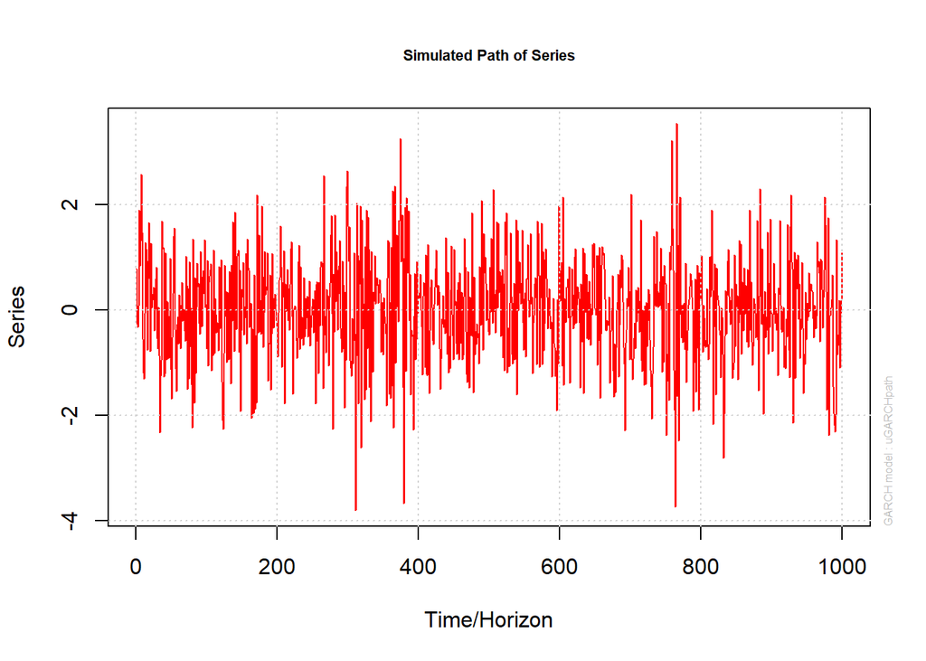

```r
set.seed(123456) # replikasyon için başlangıç
# 1000 gözlemli bir seri türet
garch11_sim = ugarchpath(garch11_spec, n.sim = 1000)
#
plot(garch11_sim, which = 2)
```

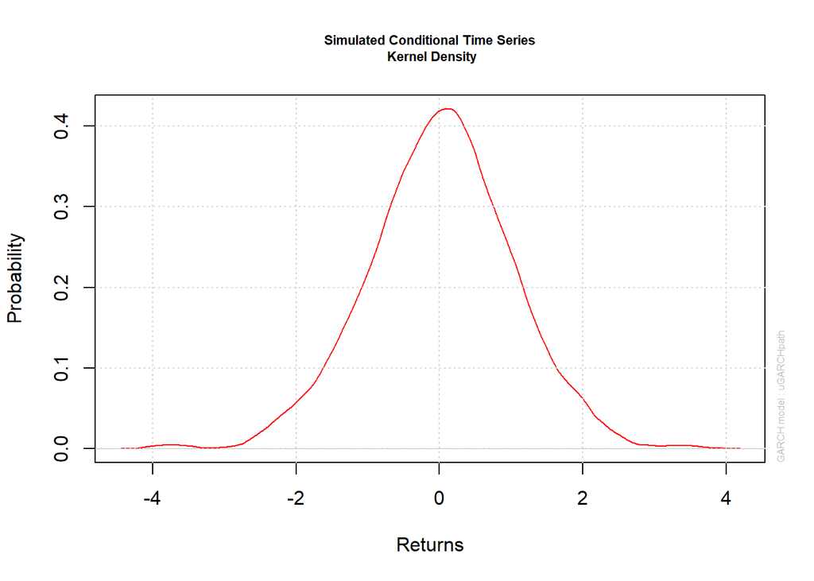

```r
# simülasyon dağılımı
plot(garch11_sim, which = 4)
```

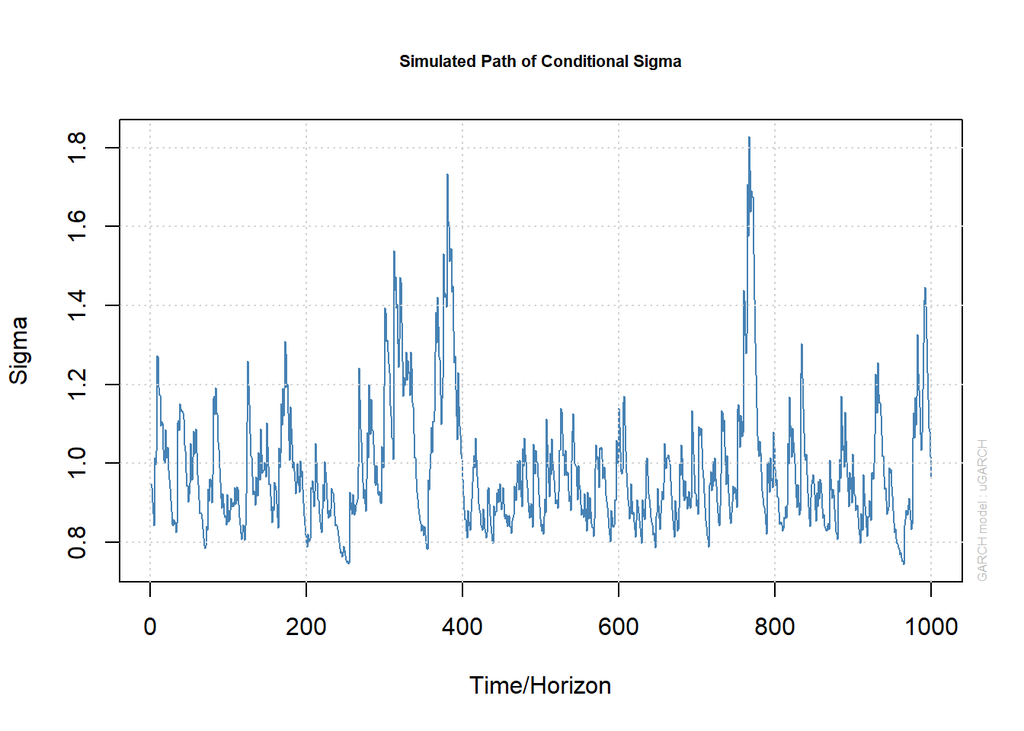

```r
# Koşullu standart sapma (koşullu volatilite) simülasyon grafiği
plot(garch11_sim, which = 1)
```

S&P500 getirileri, $r_t$, için bir GARCH(1,1) modeli tahmini:
$$r_t = \mu +
u_{t},~~~u_t\sim~Normal(0,\sigma_t^2)$$
$$\sigma_t^2\sim~GARCH(1,1)$$

```r
# sGARCH = standard GARCH
# GARCH(1,1) spesifikasyonu:
garch_spec <- ugarchspec(
  variance.model = list(model = "sGARCH",   # standart GARCH
                      garchOrder = c(1,1)), # GARCH(1,1) volatilite modeli
  mean.model = list(armaOrder = c(0,0)),    # ARMA(0,0) ortalama modeli
  distribution.model="norm")                # Hata dağılımı normal
# ekrana yaz
garch_spec
```

```
##
## *---------------------------------*
## *       GARCH Model Spec          *
## *---------------------------------*
##
## Conditional Variance Dynamics
## ------------------------------------
## GARCH Model      : sGARCH(1,1)
## Variance Targeting   : FALSE
##
## Conditional Mean Dynamics
## ------------------------------------
## Mean Model       : ARFIMA(0,0,0)
## Include Mean     : TRUE
## GARCH-in-Mean        : FALSE
##
## Conditional Distribution
## ------------------------------------
## Distribution :  norm
## Includes Skew    :  FALSE
## Includes Shape   :  FALSE
## Includes Lambda  :  FALSE
```

Ortalama modeli, varyans modeli ve alternatif şok dağılımları için `{rugarch::ugarchspec()}` fonksiyonunun yardım dosyasını inceleyiniz.

```r
garchfit <- ugarchfit(spec = garch_spec, data = sp500_returns)
coef(garchfit)
```

```
##         mu      omega     alpha1      beta1
## 0.07386740 0.03258016 0.15511545 0.82343078
```

Burada `alpha1` ARCH teriminin parametre tahminini, `beta1` ise GARCH teriminin parametre tahminini göstermektedir.

```r
print(garchfit)
```

```
##
## *---------------------------------*
## *          GARCH Model Fit        *
## *---------------------------------*
##
## Conditional Variance Dynamics
## -----------------------------------
## GARCH Model  : sGARCH(1,1)
## Mean Model   : ARFIMA(0,0,0)
## Distribution : norm
##
## Optimal Parameters
## ------------------------------------
##         Estimate  Std. Error  t value Pr(>|t|)
## mu      0.073867    0.012555   5.8834        0
## omega   0.032580    0.004156   7.8389        0
## alpha1  0.155115    0.013455  11.5288        0
## beta1   0.823431    0.013035  63.1701        0
##
## Robust Standard Errors:
##         Estimate  Std. Error  t value Pr(>|t|)
## mu      0.073867    0.011571   6.3841    0e+00
## omega   0.032580    0.006650   4.8995    1e-06
## alpha1  0.155115    0.020639   7.5157    0e+00
## beta1   0.823431    0.019199  42.8889    0e+00
##
## LogLikelihood : -5126.087
##
## Information Criteria
## ------------------------------------
##
## Akaike       2.7223
## Bayes        2.7289
## Shibata      2.7223
## Hannan-Quinn 2.7246
##
## Weighted Ljung-Box Test on Standardized Residuals
## ------------------------------------
##                         statistic  p-value
## Lag[1]                      9.959 0.001601
```

[output cut: 37 more lines]

```
## Negative Sign Bias  0.9278 3.536e-01
## Positive Sign Bias  1.5977 1.102e-01
## Joint Effect       22.3200 5.596e-05 ***
##
##
## Adjusted Pearson Goodness-of-Fit Test:
## ------------------------------------
##   group statistic p-value(g-1)
## 1    20     197.8    9.196e-32
## 2    30     216.9    1.179e-30
## 3    40     260.6    1.476e-34
## 4    50     275.1    3.196e-33
##
##
## Elapsed time : 0.2488592
```

$$\hat{\sigma}^2_{t}=\underset{(0.0067)}{0.033}+\underset{(0.0206)}{0.1551}\hspace{0.05in}\hat{u}^2_{t-1}+\underset{(0.0192)}{0.8234}\hspace{0.05in}\hat{\sigma}^2_{t-1}$$

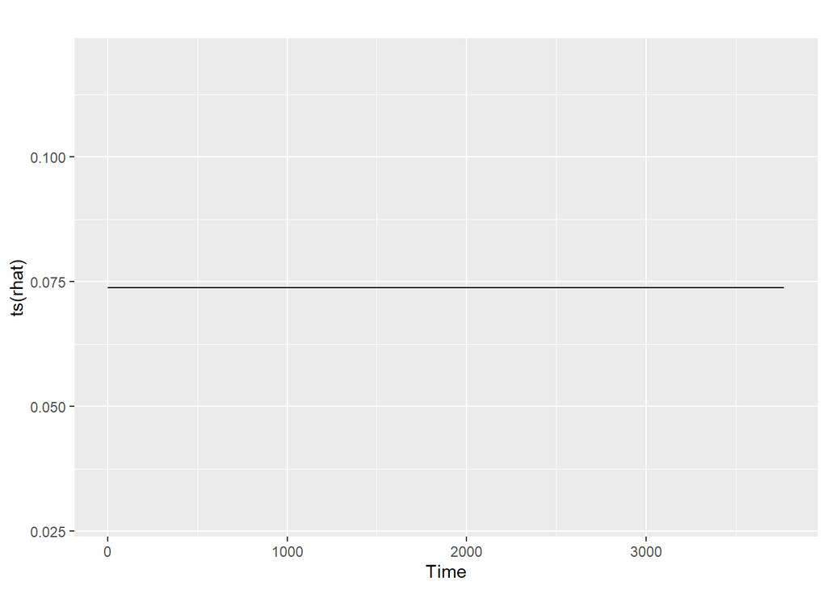

```r
rhat <- garchfit@fit$fitted.values
autoplot(ts(rhat))
```

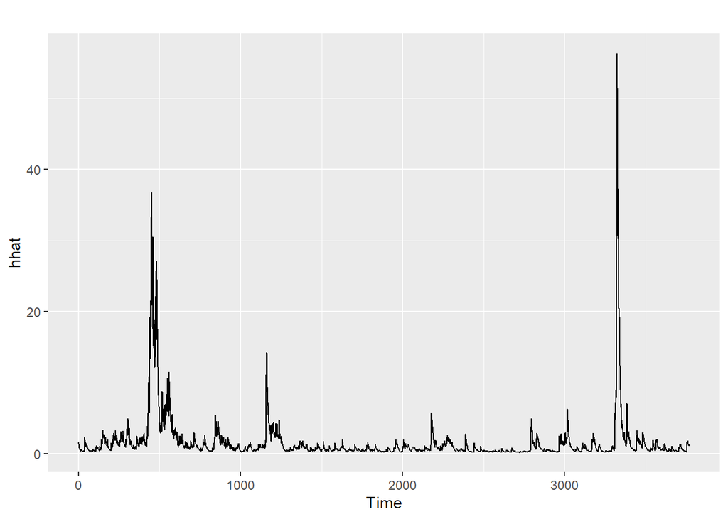

```r
hhat <- ts(garchfit@fit$sigma^2)
autoplot(hhat)
```

```
##
## please wait...calculating quantiles...
```

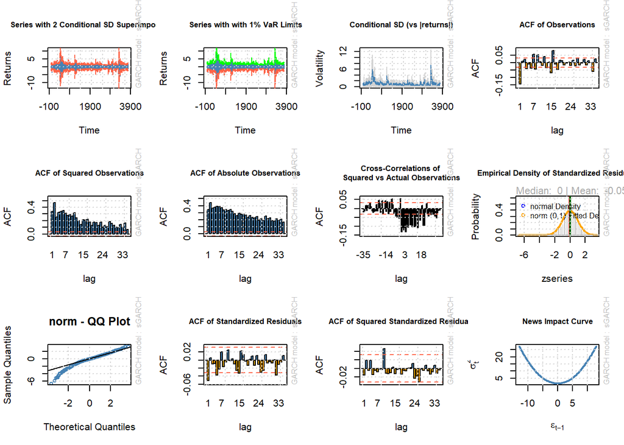

```r
# GARCH grafikleri, rugarch paketi
plot(garchfit, which="all")
```

Bu grafikleri tek tek çizmek için:

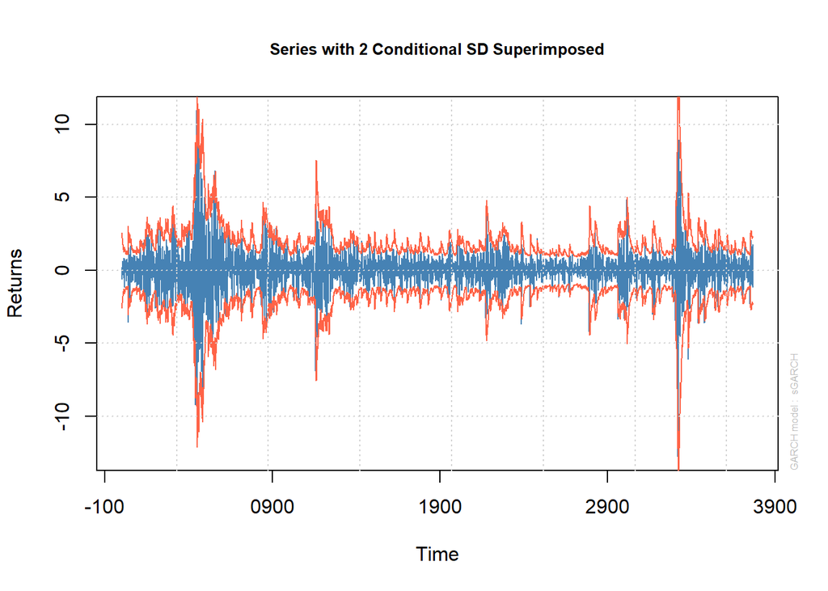

```r
plot(garchfit, which=1)
```

```
##
## please wait...calculating quantiles...
```

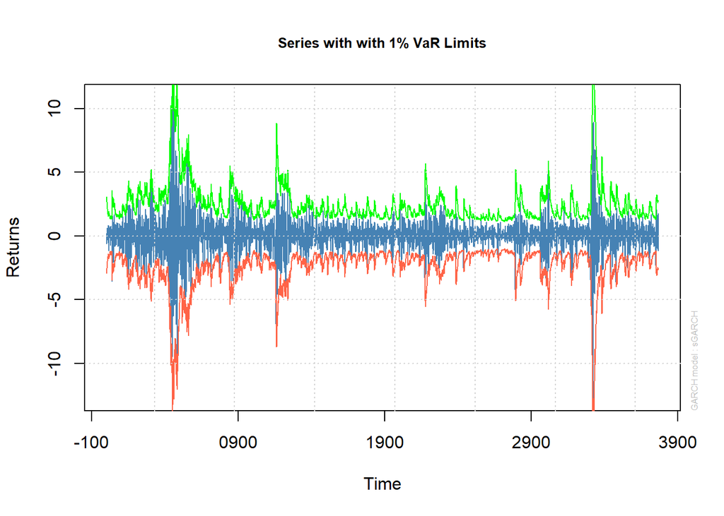

```r
plot(garchfit, which=2)
```

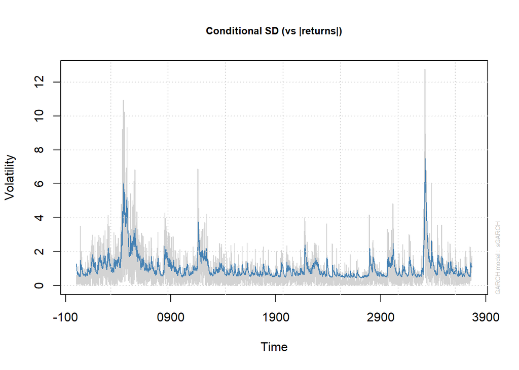

```r
plot(garchfit, which=3)
```

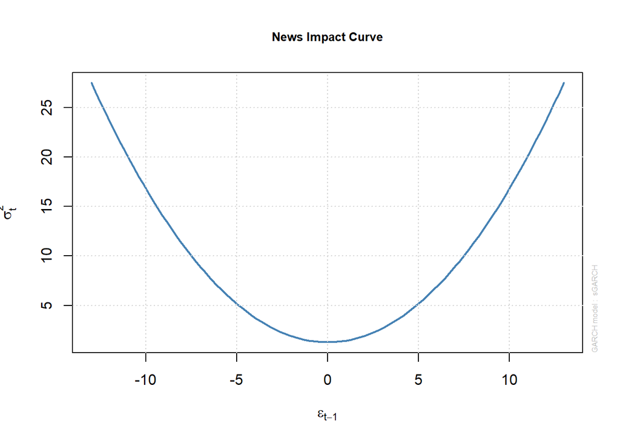

```r
# News impact curve
plot(garchfit, which=12)
```

“News impact curve” veya “haber etkisi eğrisi” önceki dönemdeki şok ile cari dönemdeki volatilite arasındaki ilişkiyi gösterir. X ekseninde şokların bir gecikmesi, Y ekseninde ise koşullu varyans yer alır. Standart GARCH modelinde negatif ve pozitif şokların volatilite üzerindeki etkisi simetriktir. Negatif şokların daha fazla volatiliteye neden olduğu duruma kaldıraç etkisi (leverage effect) adı verilir. Standart GARCH modelleri kaldıraç etkisini yakalayamaz. Bunun için asimetrik GARCH modelleri (EGARCH gibi) gerekir.

GARCH modellerinde hata dağılımını normal dışında başka bir dağılım seçebiliriz. Örneğin çarpık (skewed) t dağılımı varsayımı yapılırsa:

```r
# GARCH model with t errors
garch_spec_t <- ugarchspec(
  variance.model = list(model = "sGARCH",
                        garchOrder = c(1,1)),
  mean.model = list(armaOrder = c(0,0)),
  distribution.model = "sstd")
garch_spec_t
```

```
##
## *---------------------------------*
## *       GARCH Model Spec          *
## *---------------------------------*
##
## Conditional Variance Dynamics
## ------------------------------------
## GARCH Model      : sGARCH(1,1)
## Variance Targeting   : FALSE
##
## Conditional Mean Dynamics
## ------------------------------------
## Mean Model       : ARFIMA(0,0,0)
## Include Mean     : TRUE
## GARCH-in-Mean        : FALSE
##
## Conditional Distribution
## ------------------------------------
## Distribution :  sstd
## Includes Skew    :  TRUE
## Includes Shape   :  TRUE
## Includes Lambda  :  FALSE
```

```r
garchfit_t <- ugarchfit(spec = garch_spec_t, data = sp500_returns)
coef(garchfit_t)
```

```
##         mu      omega     alpha1      beta1       skew      shape
## 0.06700686 0.01926176 0.15860333 0.83930560 0.87811993 5.45743377
```

Return serisinin ortalaması için bir ARMA(2,1) modeli, koşullu varyans için de bir GARCH(2,1) modeli tahmin edelim:

```r
# model spesifikasyonu
garch_spec2 <- ugarchspec(
  variance.model = list(model = "sGARCH", garchOrder = c(2,1)),
  mean.model = list(armaOrder = c(2,1)),
  distribution.model = "std")
# model tahmini
garchfit2 <- ugarchfit(spec = garch_spec2, data = sp500_returns)
coef(garchfit2)
```

```
##          mu         ar1         ar2         ma1       omega      alpha1
##  0.09462570  0.83790443  0.03933895 -0.91826805  0.02899026  0.07895095
##      alpha2       beta1       shape
##  0.12211671  0.79793216  4.77872804
```

```r
print(garchfit2)
```

```
##
## *---------------------------------*
## *          GARCH Model Fit        *
## *---------------------------------*
##
## Conditional Variance Dynamics
## -----------------------------------
## GARCH Model  : sGARCH(2,1)
## Mean Model   : ARFIMA(2,0,1)
## Distribution : std
##
## Optimal Parameters
## ------------------------------------
##         Estimate  Std. Error  t value Pr(>|t|)
## mu      0.094626    0.007349  12.8760 0.000000
## ar1     0.837904    0.012214  68.6013 0.000000
## ar2     0.039339    0.015137   2.5989 0.009353
## ma1    -0.918268    0.019802 -46.3730 0.000000
## omega   0.028990    0.006235   4.6494 0.000003
## alpha1  0.078951    0.022417   3.5220 0.000428
## alpha2  0.122117    0.031268   3.9055 0.000094
## beta1   0.797932    0.021053  37.9012 0.000000
## shape   4.778728    0.390758  12.2294 0.000000
##
## Robust Standard Errors:
##         Estimate  Std. Error  t value Pr(>|t|)
## mu      0.094626    0.007782  12.1590 0.000000
## ar1     0.837904    0.018446  45.4258 0.000000
## ar2     0.039339    0.014972   2.6275 0.008603
## ma1    -0.918268    0.011236 -81.7247 0.000000
## omega   0.028990    0.006745   4.2981 0.000017
## alpha1  0.078951    0.026425   2.9877 0.002811
## alpha2  0.122117    0.034940   3.4950 0.000474
## beta1   0.797932    0.024076  33.1427 0.000000
## shape   4.778728    0.361468  13.2203 0.000000
##
## LogLikelihood : -4964.709
##
## Information Criteria
## ------------------------------------
```

[output cut: 52 more lines]

```
## Negative Sign Bias  0.2086 0.8348029
## Positive Sign Bias  1.5697 0.1165743
## Joint Effect       25.8397 0.0000103 ***
##
##
## Adjusted Pearson Goodness-of-Fit Test:
## ------------------------------------
##   group statistic p-value(g-1)
## 1    20     98.52    9.899e-13
## 2    30    126.87    3.314e-14
## 3    40    136.56    9.392e-13
## 4    50    150.67    2.817e-12
##
##
## Elapsed time : 1.218531
```

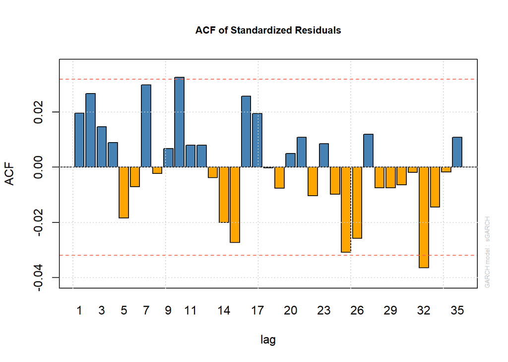

```r
# kalıntıların korelogramı
plot(garchfit2, which=10)
```

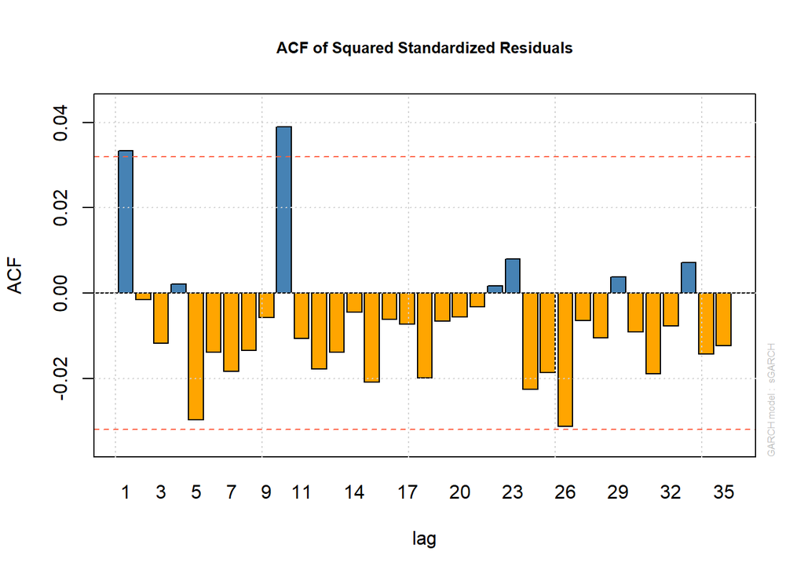

```r
# kalıntıların karesinin korelogramı
plot(garchfit2, which=11)
```

# 4 EGARCH Modeli

```r
egarch_spec <- ugarchspec(
  variance.model = list(model = "eGARCH",
                      garchOrder = c(1,1)),
  mean.model = list(armaOrder = c(1,1)),
  distribution.model = "std")
# tahmin
egarch_fit1 <- ugarchfit(spec = egarch_spec,
                         data = sp500_returns)
coef(egarch_fit1)
```

```
##          mu         ar1         ma1       omega      alpha1       beta1
##  0.06765108  0.04419029 -0.11169854 -0.01175477 -0.17880722  0.97637986
##      gamma1       shape
##  0.18563215  5.22457492
```

```r
print(egarch_fit1)
```

```
##
## *---------------------------------*
## *          GARCH Model Fit        *
## *---------------------------------*
##
## Conditional Variance Dynamics
## -----------------------------------
## GARCH Model  : eGARCH(1,1)
## Mean Model   : ARFIMA(1,0,1)
## Distribution : std
##
## Optimal Parameters
## ------------------------------------
##         Estimate  Std. Error  t value Pr(>|t|)
## mu      0.067651    0.009443   7.1643 0.000000
## ar1     0.044190    0.018542   2.3833 0.017158
## ma1    -0.111699    0.021327  -5.2374 0.000000
## omega  -0.011755    0.003604  -3.2616 0.001108
## alpha1 -0.178807    0.013112 -13.6365 0.000000
## beta1   0.976380    0.001044 935.0436 0.000000
## gamma1  0.185632    0.018253  10.1697 0.000000
## shape   5.224575    0.453846  11.5118 0.000000
##
## Robust Standard Errors:
##         Estimate  Std. Error   t value Pr(>|t|)
## mu      0.067651    0.008977    7.5364 0.000000
## ar1     0.044190    0.004293   10.2928 0.000000
## ma1    -0.111699    0.009456  -11.8122 0.000000
## omega  -0.011755    0.003918   -2.9999 0.002701
## alpha1 -0.178807    0.015243  -11.7302 0.000000
## beta1   0.976380    0.000455 2145.0400 0.000000
## gamma1  0.185632    0.022091    8.4032 0.000000
## shape   5.224575    0.468316   11.1561 0.000000
##
## LogLikelihood : -4907.903
##
## Information Criteria
## ------------------------------------
##
## Akaike       2.6086
```

[output cut: 49 more lines]

```
## Negative Sign Bias  1.7730 0.07632   *
## Positive Sign Bias  0.8295 0.40686
## Joint Effect        6.1832 0.10303
##
##
## Adjusted Pearson Goodness-of-Fit Test:
## ------------------------------------
##   group statistic p-value(g-1)
## 1    20      87.7    8.458e-11
## 2    30     116.5    1.923e-12
## 3    40     123.7    9.710e-11
## 4    50     143.6    3.176e-11
##
##
## Elapsed time : 0.8027401
```

Burada `alpha1` kaldıraç etkisini yakalamaktadır. İşareti negatif olduğu için pozitif şokların oynaklığı azalttığı, negatif şokların ise arttırdığı söylenebilir.

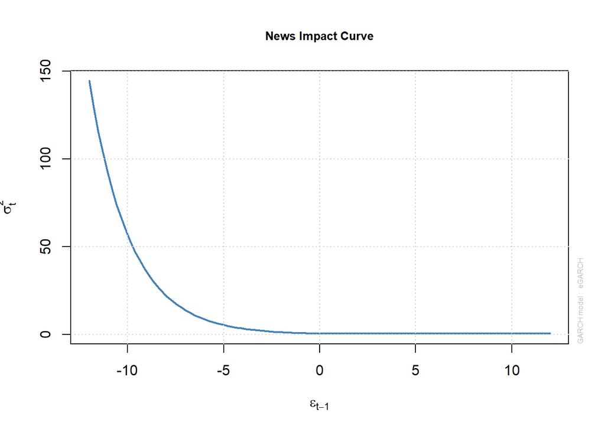

```r
# news impact curve
plot(egarch_fit1, which=12)
```

# 5 GJR

```r
gjr_spec <- ugarchspec(
  mean.model = list(armaOrder = c(1, 1)),    # getiri ortalaması için ARMA modeli
  variance.model = list(model = "gjrGARCH"), # GJR modeli
  distribution.model = "sstd"                # hata dağılımı: skewed student t
  )
# GJR estimation
gjr_fit1 <- ugarchfit(spec = gjr_spec,
                      data = sp500_returns)
coef(gjr_fit1)
```

```
##            mu           ar1           ma1         omega        alpha1
##  0.0428911014  0.5081550762 -0.5825574551  0.0232486865  0.0006106166
##         beta1        gamma1          skew         shape
##  0.8634669287  0.2377239462  0.8238017131  5.7013146887
```

```r
print(gjr_fit1)
```

```
##
## *---------------------------------*
## *          GARCH Model Fit        *
## *---------------------------------*
##
## Conditional Variance Dynamics
## -----------------------------------
## GARCH Model  : gjrGARCH(1,1)
## Mean Model   : ARFIMA(1,0,1)
## Distribution : sstd
##
## Optimal Parameters
## ------------------------------------
##         Estimate  Std. Error   t value Pr(>|t|)
## mu      0.042891    0.010877  3.943358 0.000080
## ar1     0.508155    0.157426  3.227902 0.001247
## ma1    -0.582557    0.150608 -3.868042 0.000110
## omega   0.023249    0.003649  6.371559 0.000000
## alpha1  0.000611    0.011648  0.052421 0.958193
## beta1   0.863467    0.013174 65.541550 0.000000
## gamma1  0.237724    0.029598  8.031694 0.000000
## skew    0.823802    0.019600 42.029764 0.000000
## shape   5.701315    0.545953 10.442874 0.000000
##
## Robust Standard Errors:
##         Estimate  Std. Error   t value Pr(>|t|)
## mu      0.042891    0.011062  3.877236 0.000106
## ar1     0.508155    0.190932  2.661445 0.007781
## ma1    -0.582557    0.184818 -3.152065 0.001621
## omega   0.023249    0.004801  4.842016 0.000001
## alpha1  0.000611    0.014188  0.043037 0.965672
## beta1   0.863467    0.018052 47.831344 0.000000
## gamma1  0.237724    0.042265  5.624572 0.000000
## skew    0.823802    0.021545 38.236331 0.000000
## shape   5.701315    0.558960 10.199859 0.000000
##
## LogLikelihood : -4881.594
##
## Information Criteria
## ------------------------------------
```

[output cut: 52 more lines]

```
## Negative Sign Bias  2.8040 0.0050736 ***
## Positive Sign Bias  0.8066 0.4199528
## Joint Effect       18.9088 0.0002855 ***
##
##
## Adjusted Pearson Goodness-of-Fit Test:
## ------------------------------------
##   group statistic p-value(g-1)
## 1    20     35.78      0.01123
## 2    30     47.67      0.01590
## 3    40     56.36      0.03548
## 4    50     62.16      0.09813
##
##
## Elapsed time : 1.28256
```

GJR modelinde `gamma1` parametresi kaldıraç etkisini ölçmektedir. Bu parametre pozitif ve istatistik bakımından anlamlı bulunmuştur.

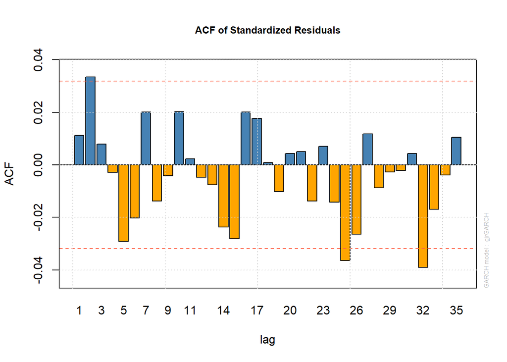

```r
# kalıntıların korelogramı
plot(gjr_fit1, which=10)
```

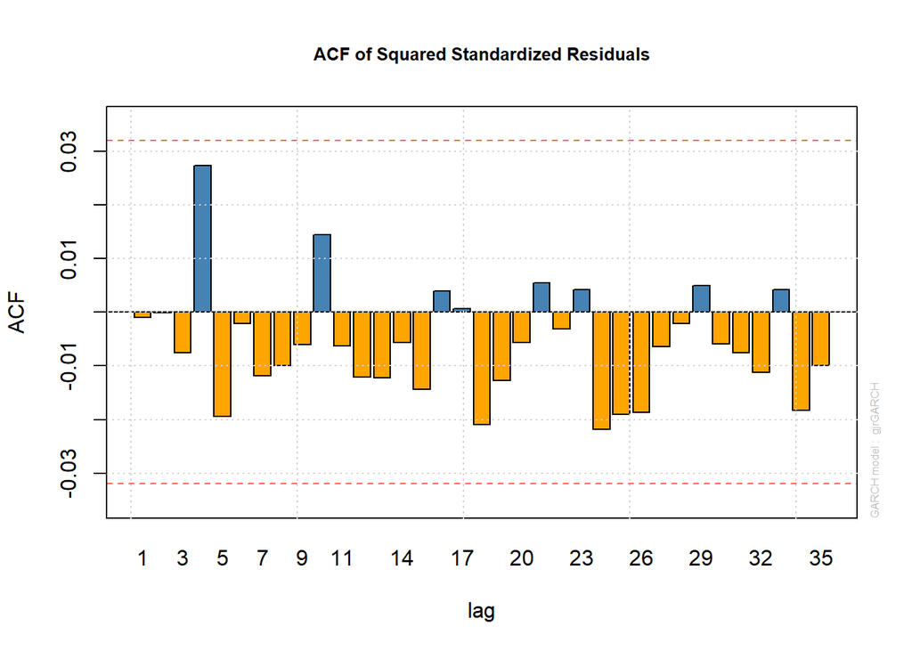

```r
# kalıntıların karesinin korelogramı
plot(gjr_fit1, which=11)
```

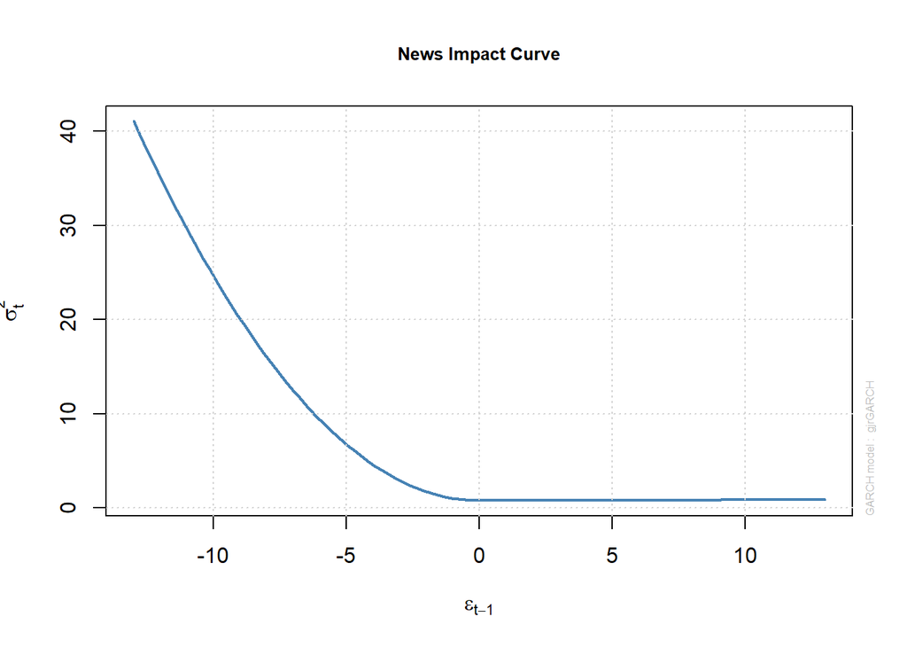

```r
# news impact curve
plot(gjr_fit1, which=12)
```

# 6 GARCH-in-mean

```r
# GARCH-in-mean
garchm_spec <- ugarchspec(
  mean.model = list(armaOrder = c(2, 1),
                    archm = TRUE,
                    archpow = 2),
  variance.model = list(model = "sGARCH"),
  distribution.model = "sstd"
  )

garchm_fit1 <- ugarchfit(spec = garchm_spec,
                         data = sp500_returns
                         )
coef(garchm_fit1)
```

```
##          mu         ar1         ar2         ma1       archm       omega
##  0.05166421 -0.85250171 -0.08588761  0.76012706  0.02462451  0.01867841
##      alpha1       beta1        skew       shape
##  0.15130792  0.84432715  0.85971042  5.50729368
```

```r
print(garchm_fit1)
```

```
##
## *---------------------------------*
## *          GARCH Model Fit        *
## *---------------------------------*
##
## Conditional Variance Dynamics
## -----------------------------------
## GARCH Model  : sGARCH(1,1)
## Mean Model   : ARFIMA(2,0,1)
## Distribution : sstd
##
## Optimal Parameters
## ------------------------------------
##         Estimate  Std. Error  t value Pr(>|t|)
## mu      0.051664    0.013177   3.9207 0.000088
## ar1    -0.852502    0.256234  -3.3270 0.000878
## ar2    -0.085888    0.022532  -3.8117 0.000138
## ma1     0.760127    0.256812   2.9599 0.003078
## archm   0.024625    0.012690   1.9405 0.052325
## omega   0.018678    0.003945   4.7342 0.000002
## alpha1  0.151308    0.015327   9.8723 0.000000
## beta1   0.844327    0.013461  62.7220 0.000000
## skew    0.859710    0.019974  43.0410 0.000000
## shape   5.507294    0.526336  10.4635 0.000000
##
## Robust Standard Errors:
##         Estimate  Std. Error  t value Pr(>|t|)
## mu      0.051664    0.011869   4.3529 0.000013
## ar1    -0.852502    0.256885  -3.3186 0.000905
## ar2    -0.085888    0.023859  -3.5997 0.000319
## ma1     0.760127    0.257331   2.9539 0.003138
## archm   0.024625    0.011575   2.1273 0.033395
## omega   0.018678    0.004012   4.6551 0.000003
## alpha1  0.151308    0.016221   9.3282 0.000000
## beta1   0.844327    0.014663  57.5826 0.000000
## skew    0.859710    0.020862  41.2088 0.000000
## shape   5.507294    0.511623  10.7644 0.000000
##
## LogLikelihood : -4955.403
##
```

[output cut: 55 more lines]

```
## Negative Sign Bias   1.877 6.054e-02   *
## Positive Sign Bias   1.679 9.325e-02   *
## Joint Effect        32.656 3.807e-07 ***
##
##
## Adjusted Pearson Goodness-of-Fit Test:
## ------------------------------------
##   group statistic p-value(g-1)
## 1    20     55.35    2.053e-05
## 2    30     71.45    1.913e-05
## 3    40     82.41    6.083e-05
## 4    50     86.47    7.667e-04
##
##
## Elapsed time : 1.883627
```

ARCHM parametresi 0.025 olarak tahmin edilmiştir. Volatilite ile getiri ortalaması arasında bir geribildirim ilişkisinden bahsedilebilir. Oynaklıktaki artış getiri ortalamasını pozitif yönde etkilemektedir.